# Verification of Ooshima & Mitamura (2025) ‘Effects of perspective-taking training based on relational frame theory for cognitive empathy and emotional empathy’

Analysis

Ian Hussey

20 May, 2025

# Dependencies

```r
library(tidyverse)
library(readxl)
library(ggstance)
library(patchwork)
library(broom)
library(janitor)
library(effectsize)
library(knitr)
library(kableExtra)
```

# Get data

```r
# data reprocessed from item level data
data_processed <- read_csv("../data/processed/data_processed.csv") |>
  # select the data after outlier exclusions and then rename the columns for simplicity
  select(id, ends_with("_outliers_excluded")) |>
  rename_with(~ str_remove(., "_outliers_excluded$"))

# data extracted from table 2 in the article
data_table_2 <- read_xlsx("../data/original/table_2.xlsx") |>
  mutate(scale_subscale = paste(scale, subscale, sep = "_")) |>
  # some rows have upper bounds of Inf as they were one sided tests.
  mutate(upper = ifelse(is.na(upper), Inf, upper))
```

# Table 2 verification

Table 2 reports *t* values and confidence intervals. I suspect these CIs are actually CIs on the difference in means between the conditions. To illustrate this point, I present this data as plots rather than tables. The first plots reported *t* values and CIs and illustrates that the estimate is outside the interval of several of them. The second plots mean differences and CIs and illustrates the mean difference is in the middle of the interval, as would be expected (except for the one sided tests, whose upper limit was Inf).

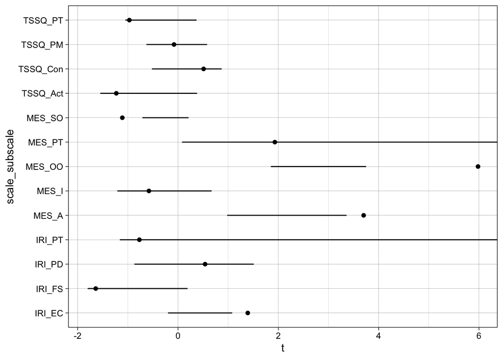

```r
ggplot(data_table_2, aes(t, scale_subscale)) +
  geom_linerangeh(aes(xmin = lower, xmax = upper)) +
  geom_point() +
  theme_linedraw()
```

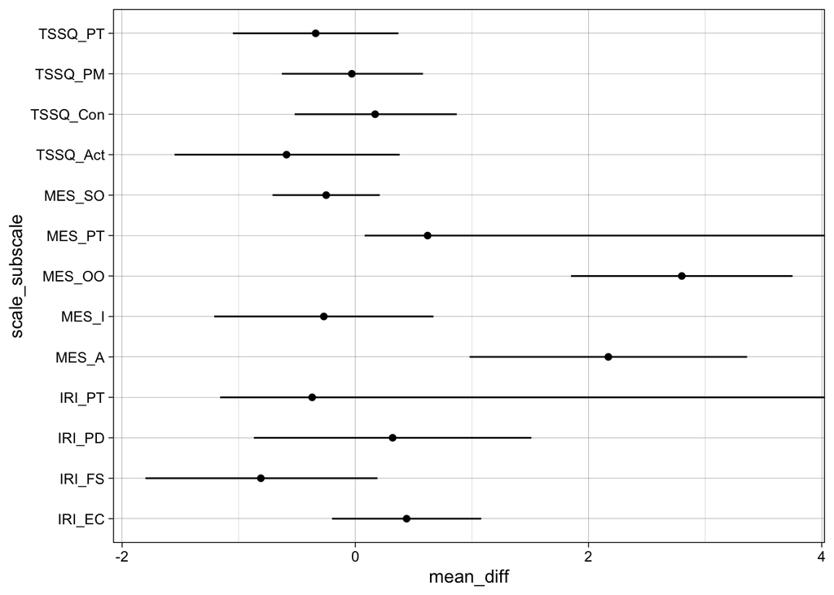

```r
ggplot(data_table_2, aes(mean_diff, scale_subscale)) +
  geom_linerangeh(aes(xmin = lower, xmax = upper)) +
  geom_point() +
  theme_linedraw()
```

# Pre-post comparisons

## F test for equal variances

```r
tidy_var_test <- function(data, pre, post, name) {
  var.test(pull(data, !!enquo(pre)),
           pull(data, !!enquo(post))) |>
    broom::tidy() |>
    mutate(outcome = name) |>
    select(outcome,
           f = statistic,
           df1 = num.df,
           df2 = den.df,
           p = p.value)
}

res_var <- bind_rows(
  tidy_var_test(data_processed, iri_pt_pre, iri_pt_post, "IRI PT"),
  tidy_var_test(data_processed, mes_perspective_pre, mes_perspective_post, "MES PT"),
  tidy_var_test(data_processed, tssq_perspective_pre, tssq_perspective_post, "TSSQ PT"),

  tidy_var_test(data_processed, iri_ec_pre, iri_ec_post, "IRI EC"),
  tidy_var_test(data_processed, iri_fs_pre, iri_fs_post, "IRI FS"),
  tidy_var_test(data_processed, iri_pd_pre, iri_pd_post, "IRI PD"),

  tidy_var_test(data_processed, mes_other_pre, mes_other_post, "MES other"),
  tidy_var_test(data_processed, mes_self_pre, mes_self_post, "MES self"),
  tidy_var_test(data_processed, mes_affected_pre, mes_affected_post, "MES affected"),
  tidy_var_test(data_processed, mes_imagination_pre, mes_imagination_post, "MES imagination"),

  tidy_var_test(data_processed, tssq_active_pre, tssq_active_post, "TSSQ active"),
  tidy_var_test(data_processed, tssq_conceptualization_pre, tssq_conceptualization_post, "TSSQ conceptualization"),
  tidy_var_test(data_processed, tssq_present_pre, tssq_present_post, "TSSQ present")
) |>
  mutate(var_equal = ifelse(p < .05, FALSE, TRUE))

res_var |>
  mutate(f = round_half_up(f, 2),
         p = round_half_up(p, 4)) |>
  kable() |>
  kable_classic(full_width = FALSE)
```

| outcome | f | df1 | df2 | p | var_equal |
| --- | --- | --- | --- | --- | --- |
| IRI PT | 1.28 | 40 | 39 | 0.4493 | TRUE |
| MES PT | 1.24 | 39 | 35 | 0.5278 | TRUE |
| TSSQ PT | 0.85 | 40 | 40 | 0.5984 | TRUE |
| IRI EC | 1.10 | 38 | 36 | 0.7858 | TRUE |
| IRI FS | 0.83 | 40 | 40 | 0.5482 | TRUE |
| IRI PD | 1.05 | 40 | 40 | 0.8693 | TRUE |
| MES other | 0.26 | 38 | 39 | 0.0001 | FALSE |
| MES self | 0.90 | 39 | 39 | 0.7407 | TRUE |
| MES affected | 0.30 | 40 | 40 | 0.0002 | FALSE |
| MES imagination | 0.30 | 40 | 40 | 0.0002 | FALSE |
| TSSQ active | 0.86 | 40 | 40 | 0.6368 | TRUE |
| TSSQ conceptualization | 1.26 | 40 | 39 | 0.4712 | TRUE |
| TSSQ present | 0.81 | 40 | 40 | 0.5084 | TRUE |

The original study reported running Welches’ t-tests for “Other-orientation, Affectedness, and Imagination subscales of the MES”. I reproduce the same conclusions, following the original study’s stated analysis. I didn’t compare the exact numerical results.

## Paired *t*-tests

### Screenshot of original article’s results:

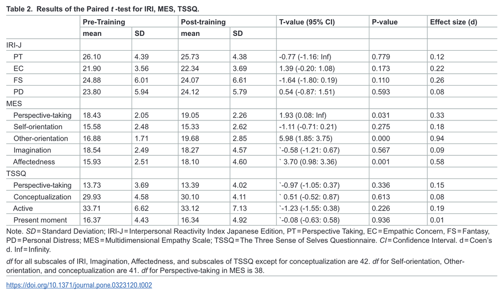

```r
knitr::include_graphics("../data/original/table_2.png")
```

The original article found significant *increases* in the following variables:

- MES PT
- MES other
- MES affectedness

### Verification:

Check that t-test is implmented correctly:

```r
# simulate data where post > pre by a lot, in a large sample
pre <- rnorm(n = 1000, mean = 0, sd = 1)
post <- rnorm(n = 1000, mean = 1, sd = 1)

t.test(post,
       pre,
       alternative = "greater",
       paired = TRUE,
       var.equal = TRUE)
```

```
##
##  Paired t-test
##
## data:  post and pre
## t = 22.953, df = 999, p-value < 2.2e-16
## alternative hypothesis: true mean difference is greater than 0
## 95 percent confidence interval:
##  0.9945792       Inf
## sample estimates:
## mean difference
##         1.07143
```

Cohen’s $d_{z}$ is approximated from the *t*-statistic and df, as in the original publication.

“One-tailed tests were conducted for PT of IRI and Perspective-taking of MES based on the research hypothesis that scores on perspective taking would increase from pre- to post-training.”

```r
tidy_t <- function(data, post, pre, var_equal, name, alternative = "two.sided"){
  t.test(pull(data, !!enquo(post)),
         pull(data, !!enquo(pre)),
         alternative = alternative,
         paired = TRUE,
         var.equal = var_equal) |>
    broom::tidy() |>
    mutate(outcome = name,
           hypothesis = alternative,
           var_equal = var_equal) |>
    select(outcome, hypothesis, var_equal,
           mean_diff = estimate, mean_diff_ci_lower = conf.low, mean_diff_ci_upper = conf.high,
           t = statistic, df = parameter, p = p.value) |>
    # cohen's d_z estimated from the the t and df.
    mutate(d_z = t / sqrt(df + 1))
}

res_t <- bind_rows(
  tidy_t(data_processed, iri_pt_post, iri_pt_pre, var_equal = TRUE, "IRI PT", alternative = "greater"),
  tidy_t(data_processed, iri_pt_post_alt, iri_pt_pre_alt, var_equal = TRUE, "IRI PT alt scoring including item 18", alternative = "greater"),
  tidy_t(data_processed, mes_perspective_post, mes_perspective_pre, var_equal = TRUE, "MES PT", alternative = "greater"),
  tidy_t(data_processed, tssq_perspective_post, tssq_perspective_pre, var_equal = TRUE, "TSSQ PT"), # , alternative = "greater" - not used in original paper, unclear to me why

  tidy_t(data_processed, iri_ec_post, iri_ec_pre, var_equal = TRUE, "IRI EC"),
  tidy_t(data_processed, iri_fs_post, iri_fs_pre, var_equal = TRUE, "IRI FS"),
  tidy_t(data_processed, iri_pd_post, iri_pd_pre, var_equal = TRUE, "IRI PD"),

  tidy_t(data_processed, mes_other_post, mes_other_pre, var_equal = FALSE, "MES other"),
  tidy_t(data_processed, mes_self_post, mes_self_pre, var_equal = TRUE, "MES self"),
  tidy_t(data_processed, mes_affected_post, mes_affected_pre, var_equal = FALSE, "MES affected"),
  tidy_t(data_processed, mes_imagination_post, mes_imagination_pre, var_equal = FALSE, "MES imagination"),

  tidy_t(data_processed, tssq_active_post, tssq_active_pre, var_equal = TRUE, "TSSQ active"),
  tidy_t(data_processed, tssq_conceptualization_post, tssq_conceptualization_pre, var_equal = TRUE, "TSSQ conceptualization"),
  tidy_t(data_processed, tssq_present_post, tssq_present_pre, var_equal = TRUE, "TSSQ present")
)

res_t |>
  mutate(mean_diff = round_half_up(mean_diff, 2),
         mean_diff_ci_lower = round_half_up(mean_diff_ci_lower, 2),
         mean_diff_ci_upper = round_half_up(mean_diff_ci_upper, 2),
         t = round_half_up(t, 2),
         p = round_half_up(p, 4),
         d_z = round_half_up(d_z, 2)) |>
  kable() |>
  kable_classic(full_width = FALSE)
```

| outcome | hypothesis | var_equal | mean_diff | mean_diff_ci_lower | mean_diff_ci_upper | t | df | p | d_z |
| --- | --- | --- | --- | --- | --- | --- | --- | --- | --- |
| IRI PT | greater | TRUE | -0.30 | -1.10 | Inf | -0.63 | 39 | 0.7336 | -0.10 |
| IRI PT alt scoring including item 18 | greater | TRUE | -0.43 | -1.23 | Inf | -0.88 | 39 | 0.8092 | -0.14 |
| MES PT | greater | TRUE | 0.71 | 0.15 | Inf | 2.15 | 34 | 0.0193 | 0.36 |
| TSSQ PT | two.sided | TRUE | -0.34 | -1.05 | 0.37 | -0.97 | 40 | 0.3355 | -0.15 |
| IRI EC | two.sided | TRUE | 0.56 | -0.21 | 1.32 | 1.47 | 35 | 0.1515 | 0.24 |
| IRI FS | two.sided | TRUE | -0.80 | -1.80 | 0.19 | -1.64 | 40 | 0.1095 | -0.26 |
| IRI PD | two.sided | TRUE | 0.32 | -0.87 | 1.51 | 0.54 | 40 | 0.5927 | 0.08 |
| MES other | two.sided | FALSE | 2.79 | 1.82 | 3.77 | 5.81 | 38 | 0.0000 | 0.93 |
| MES self | two.sided | TRUE | -0.25 | -0.71 | 0.21 | -1.11 | 39 | 0.2749 | -0.18 |
| MES affected | two.sided | FALSE | 2.17 | 0.98 | 3.36 | 3.70 | 40 | 0.0007 | 0.58 |
| MES imagination | two.sided | FALSE | -0.27 | -1.21 | 0.67 | -0.58 | 40 | 0.5669 | -0.09 |
| TSSQ active | two.sided | TRUE | -0.59 | -1.55 | 0.38 | -1.23 | 40 | 0.2262 | -0.19 |
| TSSQ conceptualization | two.sided | TRUE | 0.18 | -0.52 | 0.87 | 0.51 | 39 | 0.6130 | 0.08 |
| TSSQ present | two.sided | TRUE | -0.02 | -0.63 | 0.58 | -0.08 | 40 | 0.9359 | -0.01 |

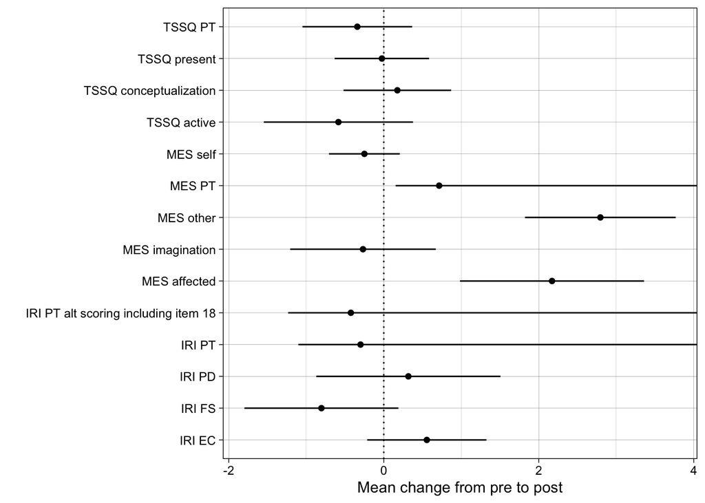

```r
ggplot(res_t, aes(mean_diff, outcome)) +
  geom_vline(xintercept = 0, linetype = "dotted") +
  ggstance::geom_linerangeh(aes(xmin = mean_diff_ci_lower, xmax = mean_diff_ci_upper)) +
  geom_point() +
  theme_linedraw() +
  scale_color_viridis_d(begin = 0.3, end = 0.7) +
  xlab("Mean change from pre to post") +
  ylab("")
```

Note that upper 95% CIs for MES PT and IRI PT are Inf because these use one-sided tests, as in the original article.

The verification analysis found significant *increases* in the following variables:

- MES PT
- MES other
- MES affectedness